# AA_MERGE

## Merge Sort

Merge Sort adalah algoritma pengurutan populer yang dikenal karena efisiensi dan stabilitasnya. Algoritma ini menggunakan pendekatan Divide and Conquer. Cara kerjanya adalah dengan membagi array input secara recursive menjadi dua bagian, mengurutkan kedua bagian tersebut secara recursive, lalu menggabungkannya kembali untuk mendapatkan array yang sudah terurut.

[figure not shown]

Berikut adalah penjelasan langkah demi langkah tentang cara kerja Merge Sort:

1. Divide: Bagi list atau array secara recursive menjadi dua bagian sampai tidak dapat dibagi lagi.
2. Conquer: Setiap sub-array diurutkan secara individual menggunakan algoritma Merge Sort.
3. Merge: Sub-array yang sudah terurut digabungkan kembali dalam urutan yang benar. Proses ini terus berlangsung sampai semua elemen dari kedua sub-array berhasil digabungkan.

Algoritma Merge Sort adalah algoritma divide-and-conquer yang mengurutkan array dengan cara membaginya terlebih dahulu menjadi array-array yang lebih kecil, kemudian menyusunnya kembali dengan urutan yang benar sehingga array menjadi terurut.

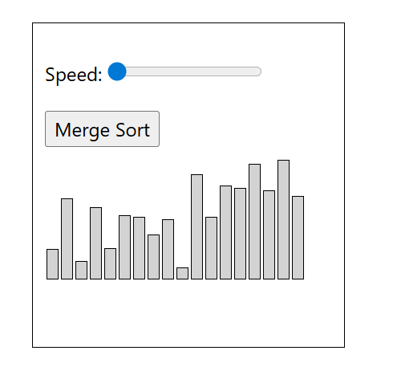

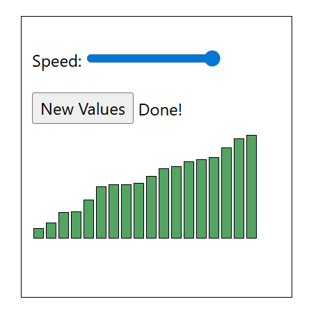

Divide: Algoritma dimulai dengan memecah array menjadi bagian-bagian yang semakin kecil hingga setiap sub-array hanya terdiri dari satu elemen.

Conquer: Algoritma kemudian menggabungkan kembali bagian-bagian kecil array tersebut dengan menempatkan nilai terkecil terlebih dahulu sehingga menghasilkan array yang terurut.

Proses memecah dan menyusun kembali array untuk melakukan pengurutan dilakukan secara recursive.

Pada animasi di atas, setiap kali batang turun berarti terjadi recursive call yang membagi array menjadi bagian yang lebih kecil. Ketika batang naik kembali, itu berarti dua sub-array telah digabungkan kembali.

Algoritma Merge Sort dapat dijelaskan seperti berikut.

Cara Kerja:

1. Bagi array yang belum terurut menjadi dua sub-array dengan ukuran setengah dari array asli.
2. Lanjutkan membagi sub-array selama bagian array saat ini masih memiliki lebih dari satu elemen.
3. Gabungkan dua sub-array dengan selalu menempatkan nilai terkecil terlebih dahulu.
4. Terus lakukan penggabungan sampai tidak ada lagi sub-array yang tersisa.

Lihat ilustrasi di bawah untuk memahami cara kerja Merge Sort dari sudut pandang yang berbeda. Seperti yang terlihat, array dibagi menjadi bagian-bagian yang semakin kecil hingga akhirnya digabungkan kembali. Saat proses penggabungan terjadi, nilai dari setiap sub-array dibandingkan agar nilai terkecil berada di depan.

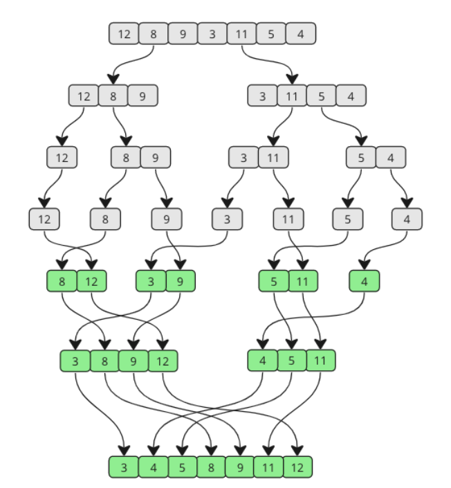

### Manual Run Through

Mari mencoba melakukan proses pengurutan secara manual agar lebih memahami bagaimana Merge Sort bekerja sebelum mengimplementasikannya menggunakan bahasa pemrograman.

Step 1: Kita mulai dengan array yang belum terurut, dan kita tahu bahwa array akan dibagi menjadi dua terus-menerus hingga setiap sub-array hanya terdiri dari satu elemen. Fungsi Merge Sort memanggil dirinya sendiri dua kali, satu untuk setiap setengah bagian array. Itu berarti sub-array pertama akan dibagi menjadi bagian terkecil terlebih dahulu.

```
[12, 8, 9, 3, 11, 5, 4]
[12, 8, 9] [3, 11, 5, 4]
[12] [8, 9] [3, 11, 5, 4]
[12] [8] [9] [3, 11, 5, 4]
```

Step 2: Proses pembagian sub-array pertama selesai, dan sekarang waktunya melakukan penggabungan. Nilai 8 dan 9 adalah dua elemen pertama yang digabungkan. Karena 8 lebih kecil daripada 9, maka 8 ditempatkan sebelum 9 pada sub-array hasil gabungan pertama.

```
[12] [8, 9] [3, 11, 5, 4]
```

Step 3: Sub-array berikutnya yang digabungkan adalah [12] dan [8, 9]. Nilai pada kedua array dibandingkan mulai dari awal. 8 lebih kecil dari 12, sehingga 8 ditempatkan terlebih dahulu, dan 9 juga lebih kecil dari 12.

```
[8, 9, 12] [3, 11, 5, 4]
```

Step 4: Sekarang sub-array besar kedua dibagi secara recursive.

```
[8, 9, 12] [3, 11, 5, 4]
[8, 9, 12] [3, 11] [5, 4]
[8, 9, 12] [3] [11] [5, 4]
```

Step 5: Nilai 3 dan 11 digabungkan kembali dalam urutan yang sama karena 3 lebih kecil dari 11.

```
[8, 9, 12] [3, 11] [5, 4]
```

Step 6: Sub-array dengan nilai 5 dan 4 dibagi, kemudian digabungkan kembali sehingga 4 berada sebelum 5.

```
[8, 9, 12] [3, 11] [5] [4]
[8, 9, 12] [3, 11] [4, 5]
```

Step 7: Dua sub-array di sebelah kanan digabungkan. Perbandingan dilakukan untuk membuat elemen pada array hasil gabungan baru.

1. 3 lebih kecil dari 4
2. 4 lebih kecil dari 11
3. 5 lebih kecil dari 11
4. 11 adalah nilai terakhir yang tersisa

   ```
    [8, 9, 12] [3, 4, 5, 11]
   ```

   Step 8: Dua sub-array terakhir digabungkan. Mari lihat lebih detail bagaimana perbandingan dilakukan untuk membentuk array hasil akhir yang sudah terurut.

3 lebih kecil dari 8

```
Before: [8, 9, 12] [3, 4, 5, 11]
After : [3, 8, 9, 12] [4, 5, 11]
```

Step 9: 4 lebih kecil dari 8

```
Before: [3, 8, 9, 12] [4, 5, 11]
After : [3, 4, 8, 9, 12] [5, 11]
```

Step 10: 5 lebih kecil dari 8

```
Before: [3, 4, 8, 9, 12] [5, 11]
After : [3, 4, 5, 8, 9, 12] [11]
```

Step 11: 8 dan 9 lebih kecil dari 11

```
Before: [3, 4, 5, 8, 9, 12] [11]
After : [3, 4, 5, 8, 9, 12] [11]
```

Step 12: 11 lebih kecil dari 12

```
Before: [3, 4, 5, 8, 9, 12] [11]
After : [3, 4, 5, 8, 9, 11, 12]
```

Proses pengurutan selesai!

Jalankan simulasi di bawah ini untuk melihat langkah-langkah di atas dalam bentuk animasi.

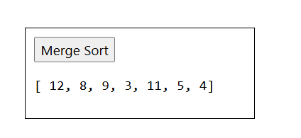

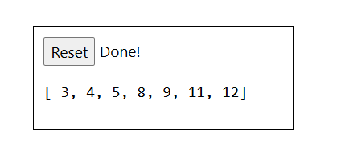

### Manual Run Through: Apa yang Terjadi?

Kita dapat melihat bahwa algoritma memiliki dua tahap utama: pertama membagi (splitting), kemudian menggabungkan (merging).

Walaupun memungkinkan untuk mengimplementasikan Merge Sort tanpa recursion, kita akan menggunakan recursion karena itu merupakan pendekatan yang paling umum.

Pada langkah-langkah di atas memang tidak terlihat secara langsung, tetapi untuk membagi array menjadi dua bagian, panjang array dibagi dua lalu dibulatkan ke bawah untuk mendapatkan nilai yang disebut "mid". Nilai "mid" ini digunakan sebagai index tempat array dibagi.

Setelah array dibagi, fungsi sorting memanggil dirinya sendiri pada masing-masing bagian sehingga array dapat dibagi lagi secara recursive. Proses pembagian berhenti ketika sub-array hanya terdiri dari satu elemen.

Pada akhir fungsi Merge Sort, sub-array digabungkan kembali sehingga sub-array selalu dalam keadaan terurut ketika array dibangun kembali. Untuk menggabungkan dua sub-array agar hasilnya terurut, nilai dari masing-masing sub-array dibandingkan, lalu nilai terkecil dimasukkan ke array hasil gabungan. Setelah itu, nilai berikutnya dari kedua sub-array dibandingkan lagi dan nilai terkecil dimasukkan ke array hasil gabungan.

### Merge Sort Implementation

Untuk mengimplementasikan algoritma Merge Sort, kita memerlukan:

1. Sebuah array berisi nilai yang ingin diurutkan.
2. Sebuah fungsi yang menerima array, membaginya menjadi dua bagian, lalu memanggil dirinya sendiri pada masing-masing bagian agar array terus dibagi secara recursive sampai sub-array hanya terdiri dari satu nilai.
3. Fungsi lain yang menggabungkan kembali sub-array secara terurut.

Kode hasil implementasinya terlihat seperti berikut.

Example

```python
def mergeSort(arr):
    if len(arr) <= 1:
        return arr

    mid = len(arr) // 2
    leftHalf = arr[:mid]
    rightHalf = arr[mid:]

    sortedLeft = mergeSort(leftHalf)
    sortedRight = mergeSort(rightHalf)

    return merge(sortedLeft, sortedRight)

def merge(left, right):
    result = []
    i = j = 0

    while i < len(left) and j < len(right):
        if left[i] < right[j]:
            result.append(left[i])
            i += 1
        else:
            result.append(right[j])
            j += 1

    result.extend(left[i:])
    result.extend(right[j:])

    return result

unsortedArr = [3, 7, 6, -10, 15, 23.5, 55, -13]
sortedArr = mergeSort(unsortedArr)
print("Sorted array:", sortedArr)
```

```
Sorted array: [-13, -10, 3, 6, 7, 15, 23.5, 55]
```

Pada baris 6, arr[:mid] mengambil semua nilai dari array sampai sebelum index "mid".

Pada baris 7, arr[mid:] mengambil semua nilai dari array mulai dari index "mid" hingga akhir array.

### Merge Sort without Recursion

Karena Merge Sort adalah algoritma divide and conquer, penggunaan recursion merupakan cara implementasi yang paling intuitif. Implementasi recursive dari Merge Sort juga biasanya lebih mudah dipahami dan menggunakan lebih sedikit baris kode.

Namun, Merge Sort juga dapat diimplementasikan tanpa menggunakan recursion, sehingga tidak ada fungsi yang memanggil dirinya sendiri.

Perhatikan implementasi Merge Sort berikut yang tidak menggunakan recursion.

Example

```python
def merge(left, right):
    result = []
    i = j = 0

    while i < len(left) and j < len(right):
        if left[i] < right[j]:
            result.append(left[i])
            i += 1
        else:
            result.append(right[j])
            j += 1

    result.extend(left[i:])
    result.extend(right[j:])

    return result

def mergeSort(arr):
    step = 1
    length = len(arr)

    while step < length:
        for i in range(0, length, 2 * step):
            left = arr[i:i + step]
            right = arr[i + step:i + 2 * step]

            merged = merge(left, right)

            for j, val in enumerate(merged):
                arr[i + j] = val

        step *= 2

    return arr

unsortedArr = [3, 7, 6, -10, 15, 23.5, 55, -13]
sortedArr = mergeSort(unsortedArr)
print("Sorted array:", sortedArr)
```

```
Sorted array: [-13, -10, 3, 6, 7, 15, 23.5, 55]
```

Kamu mungkin menyadari bahwa fungsi merge pada kedua implementasi Merge Sort di atas sebenarnya sama persis. Namun, pada implementasi terakhir tadi, while loop di dalam fungsi mergeSort digunakan untuk menggantikan recursion. While loop tersebut melakukan proses pembagian (splitting) dan penggabungan (merging) array secara langsung (in place), dan hal itu membuat kode menjadi sedikit lebih sulit dipahami.

Secara sederhana, while loop di dalam fungsi mergeSort menggunakan panjang langkah (step length) yang pendek untuk mengurutkan bagian-bagian kecil (sub-arrays) dari array awal menggunakan fungsi merge. Setelah itu, panjang langkah diperbesar untuk menggabungkan dan mengurutkan bagian array yang lebih besar sampai seluruh array menjadi terurut.

### Merge Sort Time Complexity

Time complexity untuk Merge Sort adalah:

$O(n$⋅log $n$)

Dan time complexity tersebut hampir sama untuk berbagai jenis array. Algoritma tetap perlu membagi array dan menggabungkannya kembali baik array tersebut sudah terurut maupun masih acak sepenuhnya.

Gambar di bawah menunjukkan time complexity untuk Merge Sort.

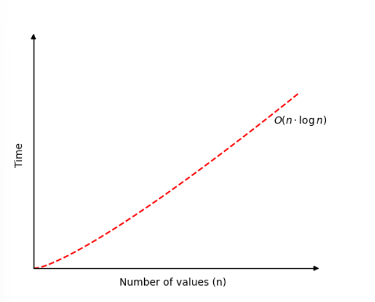

##### Time Complexity

- Best Case: O(n log n) Ketika array sudah terurut atau hampir terurut. Average Case: O(n log n) Ketika array memiliki urutan acak.
- Worst Case: O(n log n) Ketika array terurut dalam urutan terbalik (reverse order).

##### Auxiliary Space

O(n) Dibutuhkan ruang tambahan untuk array sementara (temporary array) yang digunakan selama proses merging.

### Applications of Merge Sort

- Mengurutkan dataset berukuran besar.
- External sorting (ketika dataset terlalu besar untuk dimuat ke dalam memori).
- Digunakan untuk menyelesaikan masalah seperti Inversion Counting, Count Smaller on Right, dan Surpasser Count.
- Merge Sort dan variasinya digunakan pada library method di berbagai bahasa pemrograman. Variasinya yaitu TimSort digunakan pada Python, Java Android, dan Swift. Alasan utama penggunaannya untuk mengurutkan tipe data non-primitive adalah karena sifat stability yang tidak dimiliki oleh QuickSort. Arrays.sort pada Java menggunakan QuickSort, sedangkan Collections.sort menggunakan MergeSort.
- Menjadi algoritma pilihan untuk mengurutkan Linked List.
- Mudah diparalelkan (parallelized) karena kita dapat mengurutkan sub-array secara independen lalu menggabungkannya kembali.
- Fungsi merge pada Merge Sort digunakan secara efisien untuk menyelesaikan masalah seperti union dan intersection dari dua array yang sudah terurut.

### Advantages and Disadvantages of Merge Sort

##### Advantages

- Stability: Merge Sort adalah stable sorting algorithm, yang berarti algoritma ini mempertahankan urutan relatif elemen-elemen yang memiliki nilai sama pada array input.
- Guaranteed worst-case performance: Merge Sort memiliki worst-case time complexity sebesar O(NlogN), Hal ini berarti algoritma tetap bekerja dengan baik bahkan pada dataset berukuran besar.
- Simple to implement: Pendekatan divide-and-conquer cukup sederhana untuk diimplementasikan.
- Naturally Parallel: Kita dapat menggabungkan sub-array secara independen sehingga cocok untuk parallel processing.

##### Disadvantages

- Space complexity: Merge Sort membutuhkan memori tambahan untuk menyimpan sub-array hasil penggabungan selama proses sorting.
- Not in-place: Merge Sort bukan in-place sorting algorithm, yang berarti algoritma ini memerlukan memori tambahan untuk menyimpan data yang sudah diurutkan. Hal ini bisa menjadi kekurangan pada aplikasi yang sangat memperhatikan penggunaan memori.
- Slower than QuickSort secara umum Merge Sort lebih lambat dibandingkan QuickSort karena QuickSort lebih cache friendly akibat bekerja secara in-place.